# 01 tsne clustering-based overview of eye and GTEx RNA-seq datasets

[output not shown]

## Eye

Basic tabular info on the collected eye RNA-seq data

```r
# Eye RNA-seq studies with the number of samples
core_eye_info %>% group_by(study_accession, study_title) %>% summarise(Count = n()) %>% formattable()
```

| study_accession | study_title | Count |
| --- | --- | --- |
| E_MTAB_4377 | An atlas of gene expression and gene co-regulation in the human retina | 50 |
| SRP002881 | SplicePL: de novo splice junction detection from paired-end RNA-seq reads | 1 |
| SRP011895 | Comparison of stem-cell derived retinal pigment epithelia (RPE) with human fetal retina pigment epithelium | 12 |
| SRP012585 | Identification of miRNA signatures during the differentiation of hESCs into retinal pigment epithelial cells | 10 |
| SRP015336 | Unprecedented alternative splicing and 3 Mb of novel transcribed sequence leads to significant transcript diversity in the transcriptome of the human retina | 3 |
| SRP016140 | Identification of Novel Molecular Markers through Transcriptomic Analysis in Human Fetal and Adult Corneal Endothelial Cells | 5 |
| SRP018405 | High throughput gene expression analysis identifies reliable expression markers of human corneal endothelial cells. | 4 |
| SRP034875 | Comprehensive Analysis of Gene Expression in Human Retina and Supporting Tissues | 33 |
| SRP035641 | RNA-seq analysis in Cornea epithelial cells (CECs), skin epithelial cells (SECs), LSCs after knocking down PAX6 (3-D shPAX6 LSCs) and SESCs transduced with PAX6(3-D PAX6+ SESCs) upon 3-D differentiati… | 8 |
| SRP045639 | Aneuploidy-induced cellular stresses limit autophagic degradation. | 3 |
| SRP053034 | Homo sapiens Transcriptome or Gene expression | 6 |
| SRP055101 | Transcriptomic analysis of cultured corneal endothelial cells as a validation for their use in cell-replacement therapy | 15 |
| SRP056957 | Transcriptome dynamics of developing photoreceptors in 3-D retina cultures recapitulates temporal sequence of human cone and rod differentiation revealing cell surface markers and gene networks | 23 |
| SRP057295 | Reversal of persistent wound-induced retinal pigmented epithelial-to-mesenchymal transition by the TGFb pathway inhibitor, A-83-01. | 10 |
| SRP061670 | Homo sapiens Raw sequence reads | 5 |
| SRP062870 | Deletion of DXZ4 on the human inactive X chromosome eliminates superdomains and impairs gene silencing | 12 |
| SRP064956 | mammalian cell-lines Transcriptome or Gene expression | 4 |
| SRP079002 | Enriched retinal ganglion cells derived from human embryonic stem cells (RNA-seq) | 6 |
| SRP080886 | Region-specific Transcriptome Analysis of the Human Retina and RPE/Choroid | 29 |

```r
# Number of RPE, Retina, Cornea, etc. tissues, by source (Tissue or Cell Line)
core_eye_info %>% group_by(Tissue, Origin) %>% summarise(Count=n()) %>% formattable()
```

| Tissue | Origin | Count |
| --- | --- | --- |
| Cornea | Tissue | 28 |
| ESC | Cell_Line | 14 |
| EyeLid | Tissue | 4 |
| Retina | Cell_Line | 20 |
| Retina | Tissue | 88 |
| RPE | Cell_Line | 53 |
| RPE | Tissue | 32 |

I want to see the relationships between the tissues. I expect to see retina and RPE as distinct clusters of tissues. Curious about where the cornea, eyelid, and ESCs (embryonic stem cells) end up. To judge the stability of the clustering, I’m running through perplexities 5 to 50.

```r
tsne_list = list()
# remove NA-filled samples
lengthScaledTPM <- lengthScaledTPM[,!(is.na(lengthScaledTPM[1,]))]
for (n in seq(5,50)) {
  set.seed(935489)
  tsne_out <- Rtsne(as.matrix(log2(t(lengthScaledTPM)+1)),perplexity = n, check_duplicates = FALSE, theta=0.0 )
  # Perplexity is a measure for information that is defined as 2 to the power of the Shannon entropy. The perplexity of a fair die with k sides is equal to k. In t-SNE, the perplexity may be viewed as a knob that sets the number of effective nearest neighbors. It is comparable with the number of nearest neighbors k that is employed in many manifold learners.
  tsne_plot <- data.frame(tsne_out$Y)
  tsne_plot$sample_accession <- colnames(lengthScaledTPM)
  tsne_plot$perplexity <- n
  tsne_list[[n]]<-tsne_plot
}
```

Perplexity 5 through 50

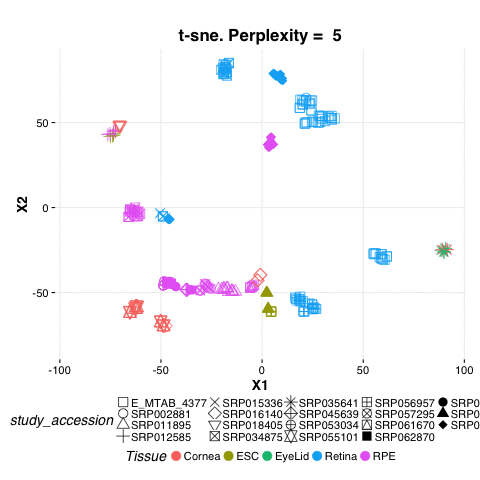

```r
plot <- long_tsne_plot %>% left_join(.,core_info) %>% filter(Tissue %in% eye_only) %>%
  ggplot(.,aes(x=X1,y=X2,colour=Tissue,shape=study_accession,frame=perplexity)) +
    geom_point(size=4) + scale_shape_manual(values=c(0:20)) +
    ggtitle(paste0("t-sne. Perplexity = ")) +
    theme_Publication()
gg_animate(plot)
```

So, retina and RPE largely stay apart. Though each has little outgroups. ESC, EyeLid, and Cornea tend to be with the RPE. Let’s try to see what each outgroup is.

Just perplexity 40:

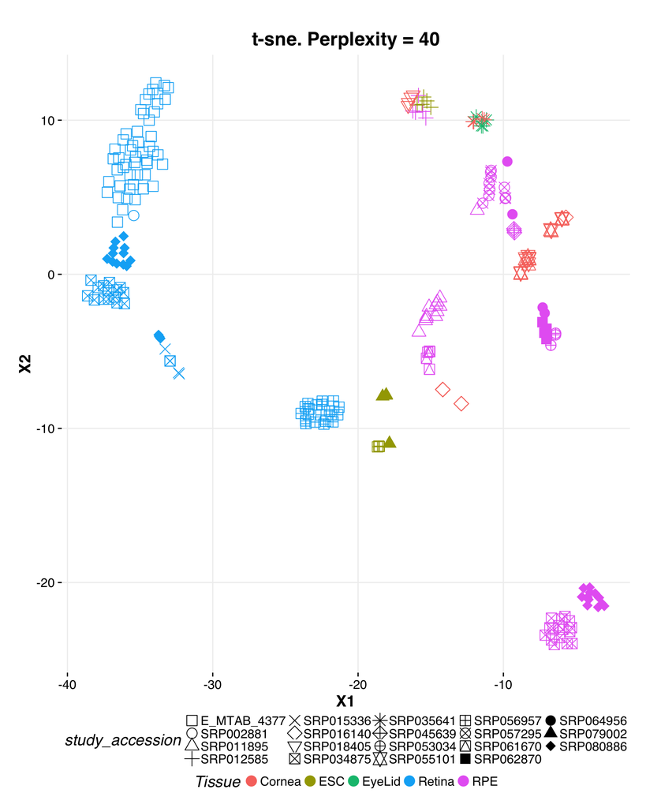

```r
long_tsne_plot %>% left_join(.,core_info) %>% filter(perplexity==40, Tissue %in% eye_only) %>%
  ggplot(.,aes(x=X1,y=X2,colour=Tissue,shape=study_accession)) +
    geom_point(size=4) + scale_shape_manual(values=c(0:20)) +
    ggtitle(paste0("t-sne. Perplexity = ", 40)) +
    theme_Publication()
```

OK, let’s colour by tissue source and only keep Retina and RPE:

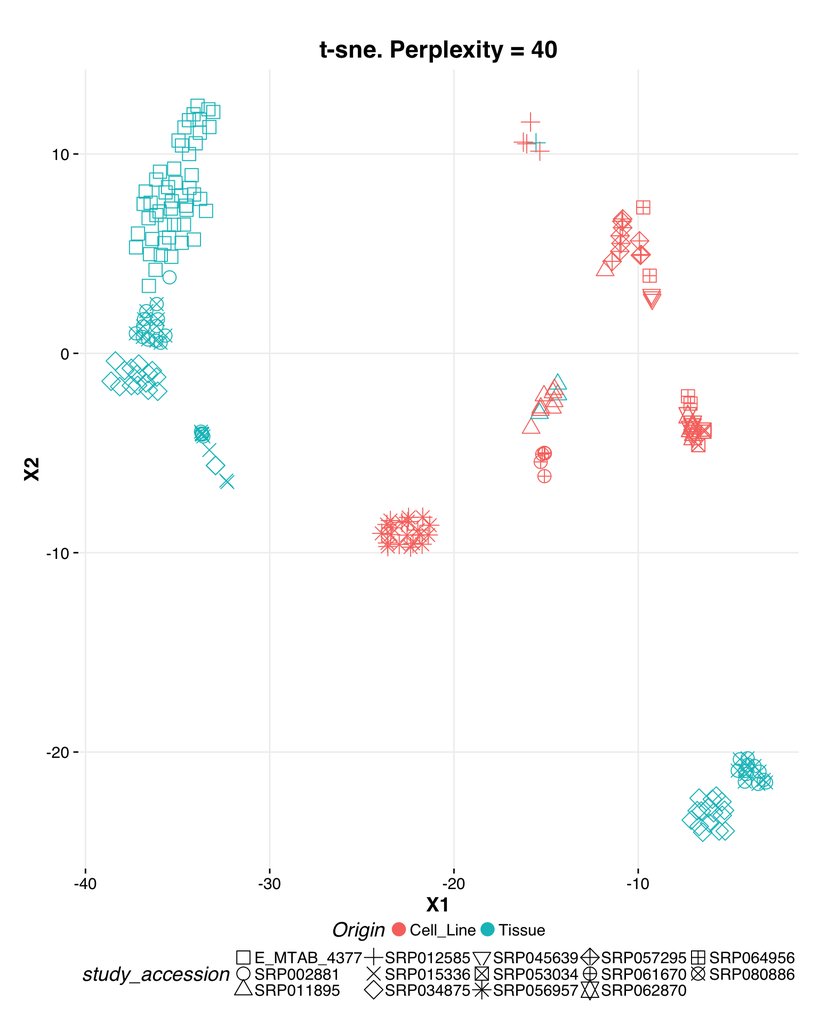

```r
long_tsne_plot %>% left_join(.,core_info) %>% filter(perplexity==40, Tissue %in% c('Retina','RPE')) %>%
  ggplot(.,aes(x=X1,y=X2,colour=Origin,shape=study_accession)) +
    geom_point(size=4) + scale_shape_manual(values=c(0:20)) +
    ggtitle(paste0("t-sne. Perplexity = ", 40)) +
    theme_Publication()
```

That retina group has a cell-line origin. Abstract for SRP056957.

| study_abstract |
| --- |
| To define molecular mechanisms underlying rod and cone differentiation, we generated H9 human embryonic stem cell line carrying a GFP reporter that is controlled by the promoter of cone-rod homeobox (… |

OK, so perhaps that should be removed from a comprehensive analysis.

What about the RPE outlier group in the lower right? Seems to be an origin thing. Let’s read the abstracts for the two studies in that group.

| study_abstract |
| --- |
| RNA-Seq of retina and RPE/choroid/sclera from 8 normal human eyes |

and

| study_abstract |
| --- |
| Proper spatial differentiation of retinal cell types is necessary for normal human vision. Many retinal diseases, such as Best disease and male germ cell associated kinase (MAK)-associated retinitis p… |

Both of these from a paired experiment where they took retina and RPE/sclera/choroid from post-mortem human eyes.

We see a FEW tissue derived RPE (the triangle group at X2=-5,X1=-15 and the plus group at X2=10, X1=-15) clustering with the cell-line-based RPE. What are these?

| Source |
| --- |
| hESC H1 line - derived RPE |
| RPE isolated from 16 weeks gestation human fetus |
| hESC H9 line - derived RPE |

| sample_attribute |
| --- |
| source_name: ES-RPE \|\| cell type: ES-RPE \|\| parental cell line: hiPS2 |
| source_name: fetal RPE \|\| cell type: primary fetal RPE |
| source_name: ESC \|\| cell type: ESC \|\| parental cell line: H9 |
| source_name: pigmented cluster \|\| cell type: pigmented cluster \|\| parental cell line: H9 |
| source_name: ES-RPE \|\| cell type: ES-RPE \|\| parental cell line: HSF1 |
| source_name: ESC \|\| cell type: ESC \|\| cell line: BG01 |
| source_name: partial differentiated ESC \|\| cell type: partial differentiated ESC \|\| parental cell line: H9 |
| source_name: partially differentiated ESC \|\| cell type: partially differentiated ESC \|\| parental cell line: BG01 |
| source_name: ES-RPE \|\| cell type: ES-RPE \|\| parental cell line: H9 |

Ah, actual fetal RPE. Suggesting that cultured RPE derived from H1/H9 ESCs are fetal-like.

## GTEx

OK, so I’ve got 19 studies worth of RNA-seq data. I’d also like to see how these relate to other human tissues. The largest go-to source is the GTEx Portal (http://www.gtexportal.org/home/), where they took tissues from hundreds of post-mortem humans. They have around **7,000** RNA-seq datasets.

I selected tissues with more than 10 female and male samples, which will skip tissues that have few samples and are gender-specific (e.g. uterus, prostate).

```r
gtex %>%
  mutate(Tissue=grab_attribute(sample_attribute,'histological type:','\\|\\|')) %>%
  mutate(Site=grab_attribute(sample_attribute,'body site:','\\|\\|')) %>%
  mutate(Gender=grab_attribute(sample_attribute,'sex:','\\|\\|')) %>%
  group_by(Tissue, Site, Gender) %>% summarise(Count=n()) %>% filter(Count>10) %>%
  group_by(Tissue, Site) %>% summarise(Count=n()) %>% filter(Count>1) %>% select(Tissue, Site) %>% formattable()
```

| Tissue | Site |
| --- | --- |
| Adipose Tissue | Adipose - Subcutaneous |
| Adipose Tissue | Adipose - Visceral (Omentum) |
| Adrenal Gland | Adrenal Gland |
| Blood | Cells - EBV-transformed lymphocytes |
| Blood | Whole Blood |
| Blood Vessel | Artery - Aorta |
| Blood Vessel | Artery - Coronary |
| Blood Vessel | Artery - Tibial |
| Brain | Brain - Amygdala |
| Brain | Brain - Anterior cingulate cortex (BA24) |
| Brain | Brain - Caudate (basal ganglia) |
| Brain | Brain - Cerebellar Hemisphere |
| Brain | Brain - Cerebellum |
| Brain | Brain - Cortex |
| Brain | Brain - Frontal Cortex (BA9) |
| Brain | Brain - Hippocampus |
| Brain | Brain - Hypothalamus |
| Brain | Brain - Nucleus accumbens (basal ganglia) |
| Brain | Brain - Putamen (basal ganglia) |
| Brain | Brain - Spinal cord (cervical c-1) |
| Brain | Brain - Substantia nigra |
| Breast | Breast - Mammary Tissue |
| Colon | Colon - Sigmoid |
| Colon | Colon - Transverse |
| Esophagus | Esophagus - Gastroesophageal Junction |
| Esophagus | Esophagus - Mucosa |
| Esophagus | Esophagus - Muscularis |
| Heart | Heart - Atrial Appendage |
| Heart | Heart - Left Ventricle |
| Liver | Liver |
| Lung | Lung |
| Muscle | Muscle - Skeletal |
| Nerve | Nerve - Tibial |
| Pancreas | Pancreas |
| Pituitary | Pituitary |
| Salivary Gland | Minor Salivary Gland |
| Skin | Cells - Transformed fibroblasts |
| Skin | Skin - Not Sun Exposed (Suprapubic) |
| Skin | Skin - Sun Exposed (Lower leg) |
| Small Intestine | Small Intestine - Terminal Ileum |
| Spleen | Spleen |
| Stomach | Stomach |
| Thyroid | Thyroid |

Lots of sub-tissues. Let’s look just by tissue.

```r
gtex %>%
  mutate(Tissue=grab_attribute(sample_attribute,'histological type:','\\|\\|')) %>%
  mutate(Site=grab_attribute(sample_attribute,'body site:','\\|\\|')) %>%
  mutate(Gender=grab_attribute(sample_attribute,'sex:','\\|\\|')) %>%
  group_by(Tissue, Site, Gender) %>% summarise(Count=n()) %>% filter(Count>10) %>%
  group_by(Tissue, Site) %>% summarise(Count=n()) %>% filter(Count>1) %>% select(Tissue) %>% distinct() %>% formattable()
```

| Tissue |
| --- |
| Adipose Tissue |
| Adrenal Gland |
| Blood |
| Blood Vessel |
| Brain |
| Breast |
| Colon |
| Esophagus |
| Heart |
| Liver |
| Lung |
| Muscle |
| Nerve |
| Pancreas |
| Pituitary |
| Salivary Gland |
| Skin |
| Small Intestine |
| Spleen |
| Stomach |
| Thyroid |

Let’s make a big t-sne plot with **all** of the tissues immediately above, RPE, and retina.

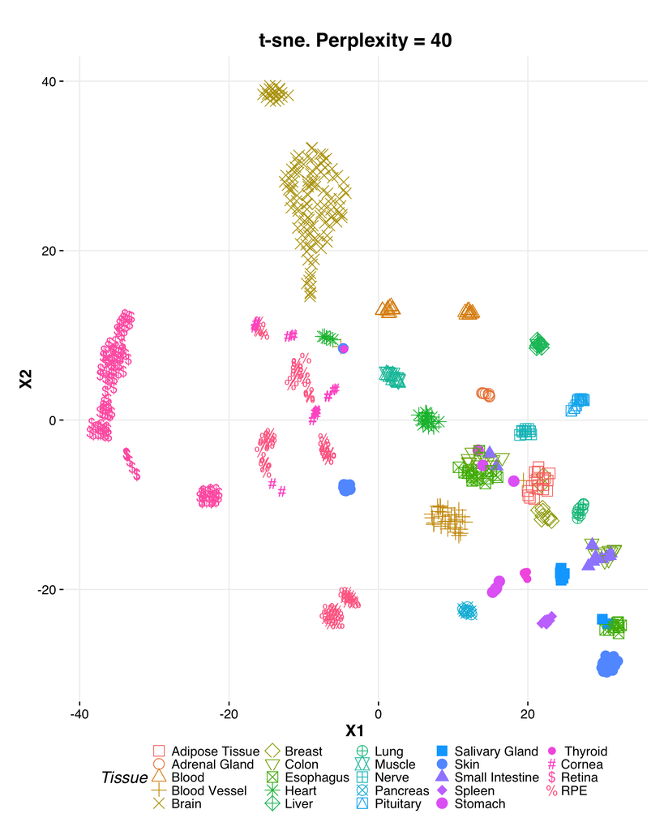

```r
long_tsne_plot %>% left_join(.,core_info) %>% filter(perplexity==40, Tissue %in% keepers) %>%
  ggplot(.,aes(x=X1,y=X2,colour=Tissue,shape=Tissue)) +
    geom_point(size=4) + scale_shape_manual(values=c(0:20,35:45)) +
    ggtitle(paste0("t-sne. Perplexity = ", 40)) +
    theme_Publication()
```

We see that, interestingly enough, that eye tissue is rather distinct from the other tissues. Also disappointing, since I was hoping to easily leverage GTEx’s eQTLs.

[figure not shown]

```r
  tsne_plot %>% left_join(.,core_info) %>% filter(Tissue %in% keepers) %>%
  ggplot(.,aes(x=X1,y=X2,colour=Tissue,shape=Tissue)) +
    geom_point(size=4) + scale_shape_manual(values=c(0:20,35:45)) +
    ggtitle(paste0("t-sne. Perplexity = ", 40)) +
    theme_Publication()
```